# Multiscale Analysis of Forest Cover

My opinionated walkthrough of the Multiscale R examples in chapter 2

# 1 Read data

## 1.1 Land cover

```r
nlcd = raster(paste0(book_data, "nlcd2011SE"))
proj4string(nlcd)
```

```
## [1] "+proj=aea +lat_1=29.5 +lat_2=45.5 +lat_0=23 +lon_0=-96 +x_0=0 +y_0=0 +ellps=GRS80 +towgs84=0,0,0,0,0,0,0 +units=m +no_defs"
```

```r
res(nlcd)
```

```
## [1] 30 30
```

## 1.2 Study site data

```r
sites = readOGR(paste0(book_data, "reptiledata"))
sites
```

```
## class       : SpatialPointsDataFrame
## features    : 85
## extent      : 812598.9, 1373597, 786930.5, 1014229  (xmin, xmax, ymin, ymax)
## crs         : NA
## variables   : 4
## names       : site,             management,   coords_x1,  coords_x2
## min values  :  AL1, Clear cut, debris left,    812598.9, 786930.525
## max values  :  TT9,         Young, Managed, 1373596.625,    1014229
```

```r
head(sites)
```

```
##   site                  management coords_x1 coords_x2
## 1  AL1                   Reference  846279.4  921444.9
## 2 AL10 Clear cut, residues removed  899063.5  989168.9
## 3 AL11              Young, Managed  898755.1  990398.2
## 4 AL12                Old, managed  867689.7 1007135.9
## 5 AL13 Clear cut, residues removed  868534.7 1001561.4
## 6 AL14          Unthinned, Managed  867288.2 1006417.8
```

Warning: There is no projection info!

Normally we should panic, but we can acertain from the book’s instructions that it is in the same projection as the land cover raster.

In real life this could be a VERY serious problem for our analyses.

```r
proj4string(sites) = proj4string(nlcd)
```

# 2 Prepare data

## 2.1 Remove all corn land use data

The book uses:

```r
sites_1 = subset(sites, management != "Corn")
```

## 2.2 Potential issues

This won’t catch data that were coded as ‘corn’ or ‘CORN’ or even ‘corn’ (with spaces). In my experience, data coding is an error-prone process so it pays to do some quality control. I would probably want to check that I wasn’t missing anything.

You could first change all of the management entries to lowercase:

```r
grep("corn", tolower(sites$management))
```

```
## [1] 20 21 48 49 70 71 76
```

You could also use the ignore.case in grep. I prefer this option.

```r
grep("corn", sites$management, ignore.case = TRUE)
```

```
## [1] 20 21 48 49 70 71 76
```

We need the management types that do not use corn. We can invert the grep output to return elements that do not match

```r
grep("corn", sites$management, ignore.case = TRUE, invert = TRUE)
```

```
##  [1]  1  2  3  4  5  6  7  8  9 10 11 12 13 14 15 16 17 18 19 22 23 24 25 26 27
## [26] 28 29 30 31 32 33 34 35 36 37 38 39 40 41 42 43 44 45 46 47 50 51 52 53 54
## [51] 55 56 57 58 59 60 61 62 63 64 65 66 67 68 69 72 73 74 75 77 78 79 80 81 82
## [76] 83 84 85
```

Do we get the same results with subset() and grep()?

```r
nrow(subset(sites, management != "Corn"))
```

```
## [1] 78
```

```r
length(grep("corn", sites$management, ignore.case = TRUE, invert = TRUE))
```

```
## [1] 78
```

At least they have the same number of records.

We could do all of this inside subset using `grepl` sites_1 = subset(sites, !grepl(“corn”, sites$management, ignore.case = TRUE))

There could still be problems though!

- `grep` and `grepl` try to match a pattern anywhere in the text.
- What if we had a management type called “not corn”?

What would you do to make sure you weren’t missing incorrectly or inconsistently recorded data?

## 2.3 crop raster to study site

### 2.3.1 The book way

It’s faster to do the crop before the factoring. There are many ways to do the cropping F&F creates an intermediate extent

```r
extent.new =
  extent(c(
    xmin = min(sites$coords_x1) - 10000,
    xmax = max(sites$coords_x1) + 10000,
    ymin = min(sites$coords_x2) - 10000,
    xmax = max(sites$coords_x2) + 10000
  ))

# nlcd_2 = crop(nlcd, extent.new)
```

### 2.3.2 Other options

Their method requires us to manually set new min and max coords for the bounding box It’s much easier, and less error prone, to buffer the extent of the sites data We get the same result with more compact and elegant code:

```r
extent(buffer(as(extent(sites), "SpatialPolygons"), 1e4)) == extent.new
```

```
## [1] TRUE
```

We can do the crop without adding an intermediate variable ‘extent.new’ to our workspace:

```r
nlcd_2 = crop(
  nlcd,
  extent(buffer(as(extent(sites), "SpatialPolygons"), 1e4))
)
nlcd_2
```

```
## class      : RasterLayer
## dimensions : 8243, 19366, 159633938  (nrow, ncol, ncell)
## resolution : 30, 30  (x, y)
## extent     : 802605, 1383585, 776925, 1024215  (xmin, xmax, ymin, ymax)
## crs        : +proj=aea +lat_1=29.5 +lat_2=45.5 +lat_0=23 +lon_0=-96 +x_0=0 +y_0=0 +ellps=GRS80 +towgs84=0,0,0,0,0,0,0 +units=m +no_defs
## source     : C:/Users/michaelnelso/AppData/Local/Temp/Rtmp0kyLXx/raster/r_tmp_2020-01-30_124034_12040_91075.grd
## names      : nlcd2011SE
## values     : 0, 95  (min, max)
```

## 2.4 Factor land cover data

Now convert the crooped raster to a factor:

```r
nlcd_f = as.factor(nlcd_2)
```

## 2.5 Reclassify land cover to forest/non-forest

The text tells us that categories 41, 42, and 43 are forest

```r
levels(nlcd_f)
```

```
## [[1]]
##    ID
## 1   0
## 2  11
## 3  21
## 4  22
## 5  23
## 6  24
## 7  31
## 8  41
## 9  42
## 10 43
## 11 52
## 12 71
## 13 81
## 14 82
## 15 90
## 16 95
```

We can use a handy operator to tell us which levels match 41, 42, or 43

```r
levels(nlcd_f)[[1]][, 1] %in% 41:43
```

```
##  [1] FALSE FALSE FALSE FALSE FALSE FALSE FALSE  TRUE  TRUE  TRUE FALSE FALSE
## [13] FALSE FALSE FALSE FALSE
```

We could coerce boolean to integer

```r
cbind(
  ID = levels(nlcd_f)[[1]],
  reclass = as.integer(levels(nlcd_f)[[1]][, 1] %in% 41:43)
)
```

```
##    ID reclass
## 1   0       0
## 2  11       0
## 3  21       0
## 4  22       0
## 5  23       0
## 6  24       0
## 7  31       0
## 8  41       1
## 9  42       1
## 10 43       1
## 11 52       0
## 12 71       0
## 13 81       0
## 14 82       0
## 15 90       0
## 16 95       0
```

Here’s a trick to implicitly coerce: add 0 to boolean to get an integer

```r
cbind(
  ID = levels(nlcd_f)[[1]],
  reclass = 0 + levels(nlcd_f)[[1]][, 1] %in% 41:43
)
```

```
##    ID reclass
## 1   0       0
## 2  11       0
## 3  21       0
## 4  22       0
## 5  23       0
## 6  24       0
## 7  31       0
## 8  41       1
## 9  42       1
## 10 43       1
## 11 52       0
## 12 71       0
## 13 81       0
## 14 82       0
## 15 90       0
## 16 95       0
```

This trickery only works because we were reclassifying as 0 or 1.

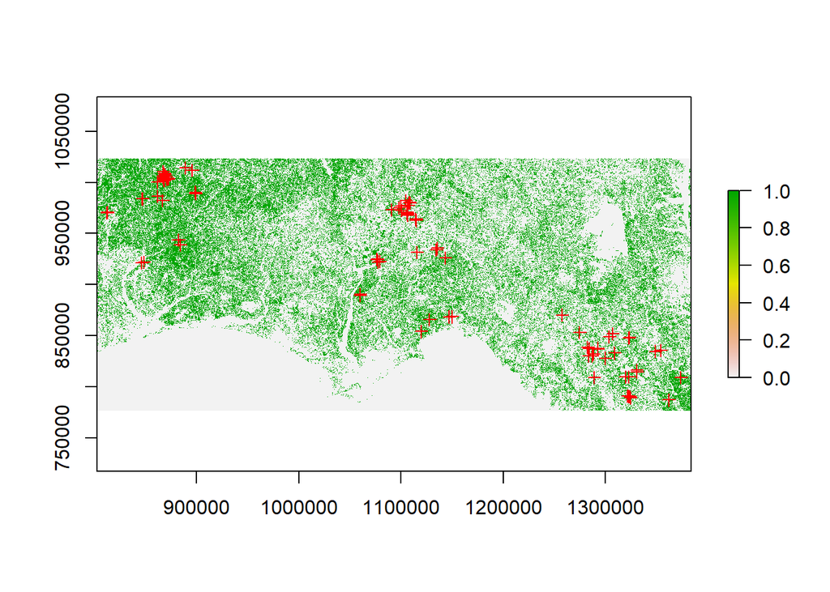

```r
forest = reclassify(
  nlcd_f,
  cbind(
    ID = levels(nlcd_f)[[1]],
    reclass = 0 + levels(nlcd_f)[[1]][, 1] %in% 41:43
  )
)
plot(forest)
plot(sites_1, add = T)
plot(sites, add = T, col = 2)
```